# Prática 2: Avaliação da qualidade da água de rios e lagoas urbanizados

Guilherme Rodrigues

21 de fevereiro de 2026

Uma pesquisa avaliou a qualidade da água de rios e lagoas urbanizados de um grande município. Amostras foram retiradas de vários pontos de cada local e organizadas num banco de dados no Excel. As informações coletadas foram:

1. Identificação da amostra;
2. Nome do local;
3. Presença de coliformes;
4. Presença de criadouro durante a visita;
5. Valor de nitrato, em mg/L.
6. Valor de PH.

```r
library(readxl)
dados <- read_excel("dados.xlsx")
head(dados)
```

| ID | Identificacao | Local | Presenca_Coliforme | Nitrato | PH |
| --- | --- | --- | --- | --- | --- |
| 1 | 11182 | Lagoa Branca | Presente | 10.8 | 8.9 |
| 2 | 11029 | Lagoa Branca | Presente | 12.3 | 11.0 |
| 3 | 14905 | Lagoa Branca | Presente | 13.1 | 7.0 |
| 4 | 10258 | Lagoa Branca | Presente | 9.7 | 10.9 |
| 5 | 13351 | Lagoa Branca | Presente | 12.4 | 9.0 |
| 6 | 13503 | Lagoa Branca | Presente | 12.5 | 5.0 |

Responda as perguntas abaixo:

**a)** Classifique cada uma das variáveis do estudo.

**Resposta:** As variáveis do estudo são:

```r
names(dados)
```

```
## [1] "ID"                 "Identificacao"      "Local"
## [4] "Presenca_Coliforme" "Nitrato"            "PH"
```

Logo, as classificações são dadas por:

- Identificação da amostra: Qualitativa nominal (Variável identificadora)
- Nome do local: Qualitativa nominal
- Presença de coliformes: Qualitativa nominal de característica dictômica presente/ausente
- Valor de Nitrato: Quantitativa contínua
- Valor de PH: Quantitativa contínua

**b)** Verifique a existência de pontos discrepantes de nitrato e PH por meio de gráficos e estatísticas descritivas. Realize a correção das informações implausíveis, visto que houve o esquecimento do ponto como erro de digitação.

**Resposta:** A priori vamos verificar a existência de pontos discrepantes dos valores de Nitrato e PH utilizando boxplots e estatísticas descritivas.

```r
summary(dados$Nitrato)
```

```
##    Min. 1st Qu.  Median    Mean 3rd Qu.    Max.    NA's
##    5.40    8.45    9.50   10.01   11.20   20.20       1
```

```r
summary(dados$PH)
```

```
##    Min. 1st Qu.  Median    Mean 3rd Qu.    Max.    NA's
##   3.900   6.000   8.100   7.831  10.000  11.100       8
```

Aqui já podemos verificar que existem informações implausíveis, dado que para os valores de nitrato registrados um está faltando, e nos valores de PH registrados, temos 8 faltantes. Uma forma de resolver isso é substituir os valores faltantes pela mediana do grupo local, assim evitamos a distorção dos dados. Além disso, temos uma quantidade baixa de dados faltantes em cada variável:

```r
sum(is.na(dados$PH)) / nrow(dados) * 100
```

```
## [1] 4
```

```r
sum(is.na(dados$Nitrato)) / nrow(dados) * 100
```

```
## [1] 0.5
```

```r
print(paste("Percentual de dados faltantes em PH:",
            round(sum(is.na(dados$PH)) / nrow(dados) * 100, 2), "%"))
```

```
## [1] "Percentual de dados faltantes em PH: 4 %"
```

```r
print(paste("Percentual de dados faltantes em Nitrato:",
            round(sum(is.na(dados$Nitrato)) / nrow(dados) * 100, 2), "%"))
```

```
## [1] "Percentual de dados faltantes em Nitrato: 0.5 %"
```

Portanto, fazendo o preenchimento dos dados faltantes com a mediana do grupo local, temos:

```r
dados$PH[is.na(dados$PH)] <- ave(dados$PH, dados$Local,
                      FUN = function(x) median(x, na.rm = TRUE))[is.na(dados$PH)]

dados$Nitrato[is.na(dados$Nitrato)] <- ave(dados$Nitrato, dados$Local,
                      FUN = function(x) median(x, na.rm = TRUE))[is.na(dados$Nitrato)]
```

Agora podemos verificar que não há mais dados faltantes em PH:

```r
sum(is.na(dados$PH))
```

```
## [1] 0
```

```r
sum(is.na(dados$Nitrato))
```

```
## [1] 0
```

E as estatísticas descritivas atualizadas para pH e Nitrato são, respectivamente:

```r
summary(dados$PH)
```

```
##    Min. 1st Qu.  Median    Mean 3rd Qu.    Max.
##   3.900   6.000   8.100   7.853   9.900  11.100
```

```r
summary(dados$Nitrato)
```

```
##    Min. 1st Qu.  Median    Mean 3rd Qu.    Max.
##   5.400   8.475   9.500  10.024  11.225  20.200
```

Agora vamos verificar a existência de pontos discrepantes utilizando o boxplot:

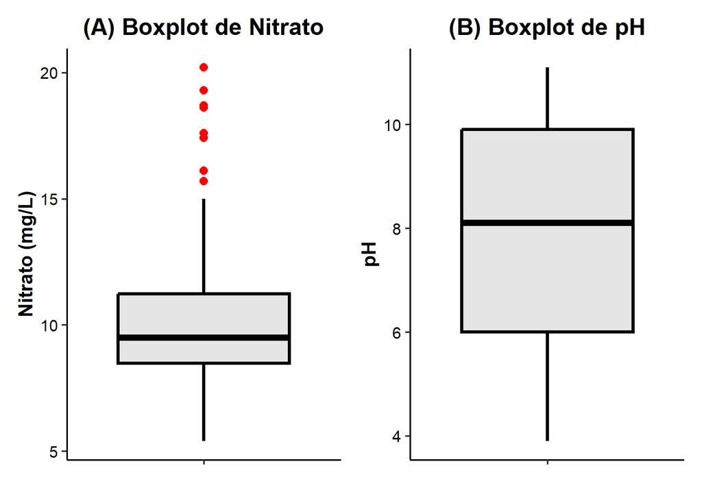

```r
library(ggplot2)
library(patchwork)
library(scales)
# Boxplot de Nitrato
boxplot_nitrato <- ggplot(dados, aes(x = "", y = Nitrato)) +
  geom_boxplot(fill = "grey90", color = "black",
               size = 1.1, outlier.colour = "red", outlier.size = 2.5) +
  labs(title = "(A) Boxplot de Nitrato", x = NULL, y = "Nitrato (mg/L)") +
  theme_classic(base_size = 14) +
  theme(
    plot.title = element_text(hjust = 0.5, face = "bold"),
    axis.title.y = element_text(face = "bold"),
    axis.text = element_text(color = "black")
  )

# Boxplot de PH
boxplot_ph <- ggplot(dados, aes(x = "", y = PH)) +
  geom_boxplot(fill = "grey90", color = "black",
               size = 1.1, outlier.colour = "red", outlier.size = 2.5) +
  labs(title = "(B) Boxplot de pH", x = NULL, y = "pH") +
  theme_classic(base_size = 14) +
  theme(
    plot.title = element_text(hjust = 0.5, face = "bold"),
    axis.title.y = element_text(face = "bold"),
    axis.text = element_text(color = "black")
  )

boxplot_nitrato + boxplot_ph
```

Os boxplots permitem visualizar a distribuição dos dados de pH e Nitrato. Observa-se que o pH apresentou valores entre 3,9 e 11,1, com mediana de 8,1, estando a maior parte das observações (50%) entre 6,0 e 9,9. Esse resultado indica uma predominância de valores próximos à neutralidade, mas com variação considerável, o que sugere diferenças entre locais ou momentos de coleta. Já o Nitrato variou entre 5,4 e 20,2 mg/L, com mediana de 9,5 e média de 10,0. Apesar de a maior parte das amostras se concentrar entre 8,5 e 11,2, há presença de outliers acima de 15 mg/L, indicando pontos de maior concentração possivelmente relacionados a fontes específicas de contaminação. Em conjunto, os resultados evidenciam que, enquanto o pH se mantém dentro de uma faixa relativamente ampla, o nitrato apresenta dispersão menor, mas com valores extremos que podem demandar atenção do ponto de vista ambiental.